# Commitment of Trades and Twitter Sentiment

Lou Zhang

May 12, 2017

## Introduction

This document investigates the relationship between the commitment of trades and Twitter sentiment. Commitment of trades data is provided by the CFTC and outlines aggregated trading activity for crude oil, including end-of-week swap positions and number of trades. Twitter sentiment is provided by Social Media Analytics, and quantifies aggregate Twitter sentiment towards crude oil in terms of standard deviations from the mean sentiment.

```r
#import reference tables and peek at the top 10 rows and a couple columns of each

cot <- read.csv('cftc.csv')

head(cot[,c(5,10:12)], 10)
```

```
##    report_date_as_yyyy_mm_dd open_interest_all
## 1                  1/18/2011            971444
## 2                  3/15/2011            895870
## 3                  5/10/2011            966619
## 4                   7/5/2011            871267
## 5                  8/30/2011            885676
## 6                 10/25/2011           1090030
## 7                 12/20/2011            975361
## 8                  1/17/2012           1060735
## 9                  3/13/2012           1290005
## 10                 2/15/2011            901967
##    prod_merc_positions_long_all prod_merc_positions_short_all
## 1                        361798                        582167
## 2                        301101                        514494
## 3                        338066                        530971
## 4                        295304                        464687
## 5                        294062                        420495
## 6                        394855                        463035
## 7                        336372                        421635
## 8                        316128                        459117
## 9                        399201                        599717
## 10                       316512                        529619
```

```r
twitterSentiment <- read.csv("output.csv")

head(twitterSentiment[,1:7], 10)
```

```
##    ticker           date raw.s raw.s.mean raw.volatility raw.score     s
## 1    CL_F 9/2/2009 15:55 0.250      0.012          0.056     4.249 0.249
## 2    CL_F 9/2/2009 16:10 0.250      0.012          0.056     4.249 0.246
## 3    CL_F 9/2/2009 16:25 0.250      0.012          0.056     4.249 0.244
## 4    CL_F 9/2/2009 16:40 0.250      0.012          0.056     4.249 0.241
## 5    CL_F 9/2/2009 16:55 0.500      0.025          0.112     4.249 0.487
## 6    CL_F 9/2/2009 17:10 0.500      0.025          0.112     4.249 0.482
## 7    CL_F 9/2/2009 17:25 0.500      0.025          0.112     4.249 0.477
## 8    CL_F 9/2/2009 17:40 0.500      0.025          0.112     4.249 0.472
## 9    CL_F 9/2/2009 17:55 0.536      0.027          0.120     4.249 0.503
## 10   CL_F 9/2/2009 18:10 0.536      0.027          0.120     4.249 0.498
```

## Data Cleaning

The data clearly needs to be cleaned and re-aggregated as they contain different (but overlapping) time periods as well as different recording frequencies. First, we focus on the cleaning the COT data.

```r
#create a datetime stamp
cot$datetime <- as.Date(cot$report_date_as_yyyy_mm_dd,"%m/%d/%Y")

#restrict to only crude oil data
cotDisagg <- cot[cot$sourceset == 'COTD',]
cotDisagg <- cot[cot$cftc_commodity_code == '67',]

#aggregate data from different indices and different types of crude oil together
cotDisagg <- aggregate(x = cotDisagg[,c(10:187)],
                              by = list(unique.values = cotDisagg$datetime), FUN = sum)


#create variables necessary for clean merging and organize table
cotDisagg$datetime <- cotDisagg$unique.values

cotDisagg <- orderBy(~datetime, data = cotDisagg)

cotDisaggCleaned <- cotDisagg

cotDisaggCleaned[is.na(cotDisaggCleaned)] <- 0

#peek at cleaned dataframe
head(cotDisaggCleaned[,1:3], 10)
```

```
##    unique.values open_interest_all prod_merc_positions_long_all
## 1     2011-01-04           6775051                      1227834
## 2     2011-01-11           6985813                      1291446
## 3     2011-01-18           6919228                      1333278
## 4     2011-01-25           6996976                      1381056
## 5     2011-02-01           7274386                      1397018
## 6     2011-02-08           7286226                      1420104
## 7     2011-02-15           7370128                      1399122
## 8     2011-02-22           7231904                      1347691
## 9     2011-03-01           7524034                      1331088
## 10    2011-03-08           7752215                      1333153
```

After we clean the COT data, we focus our attention on the Twitter sentiment data. This requires considerable cleaning as well to be in a usable form, especially in the time domain.

```r
#cleaning time periods and creating appropriate column names

twitterSentiment$center.date <- as.Date(twitterSentiment$center.date,"%m/%d/%Y")

tweetsAggregated <- aggregate(x = twitterSentiment,
                              by = list(unique.values = twitterSentiment$center.date), FUN = mean)

tweetsAggregated$unique.values <- gsub(" ","",x = tweetsAggregated$unique.values)

tweetsAggregatedClean <- tweetsAggregated

tweetsAggregatedClean$unique.values <- gsub("/","-",x = tweetsAggregatedClean$unique.values)

tweetsAggregatedClean <- separate(tweetsAggregatedClean, col = unique.values, into = c("Month","Day","Year"), sep = "-")

tweetsAggregatedClean$datetime <- tweetsAggregatedClean$center.date

tweetsAggregatedClean <- orderBy(~datetime, data = tweetsAggregatedClean)

tweetsAggregatedClean <- Filter(function(x)!all(is.na(x)), tweetsAggregatedClean)

#aggregate Twitter data by week, starting 12/28/2010 (a week before COT data starts)

tweetsAggregatedClean <- tweetsAggregatedClean[tweetsAggregatedClean$datetime >= '2010-12-28',]

datetimes <- tweetsAggregatedClean$datetime

datetimes <- datetimes[seq(1, length(datetimes), 7)]

tweetsAggregatedCleanWeekly <- tweetsAggregatedClean[,4:(ncol(tweetsAggregatedClean)-2),]

tweetsAggregatedCleanWeekly$seven_day_index <- c(0, rep(1:(nrow(tweetsAggregatedCleanWeekly)-1)%/%7))

tweetsAggregatedCleanWeekly <- group_by(tweetsAggregatedCleanWeekly, seven_day_index) %>%
  summarise_all(.funs = mean)

#lag Twitter data to be the week before, as COT data is for the week before

colnames(tweetsAggregatedCleanWeekly) <- paste('PriorWeek', colnames(tweetsAggregatedCleanWeekly), sep = "")

a <- as.data.frame(1:nrow(tweetsAggregatedCleanWeekly))
list_names <- colnames(tweetsAggregatedCleanWeekly)

for(i in 1:ncol(tweetsAggregatedCleanWeekly)){

  b <- as.data.frame(lag(tweetsAggregatedCleanWeekly[[i]]))
  a <- cbind(a,b)

}

tweetsAggregatedCleanWeekly <- a[,2:ncol(a)]
colnames(tweetsAggregatedCleanWeekly) <- list_names

tweetsAggregatedCleanWeekly$datetime <- datetimes

#peek at cleaned data

head(tweetsAggregatedCleanWeekly[,1:3], 10)
```

```
##    PriorWeekseven_day_index PriorWeekraw.s PriorWeekraw.s.mean
## 1                        NA             NA                  NA
## 2                         0    -0.51236210           0.4530997
## 3                         1     0.19920766           0.1934942
## 4                         2     1.76738558           0.2949703
## 5                         3     1.34026395           0.7987016
## 6                         4     0.87085975           1.2461978
## 7                         5     0.03714583           0.9226920
## 8                         6     0.79669363           0.6348598
## 9                         7     0.46541626           0.3026188
## 10                        8     2.59052530           0.9814435
```

After cleaning both dataframes, we then proceed to join them before furthering our analysis. We also engineer a key variable, “Net Length”, as advised by subject matter expert Karim Fawaz. “Net Length” is calculated by taking the difference in the change of long positions to the change in short positions. It is effectively a representation of how bullish (high net length) or bearish (low or negative net length) the market is, and should in theory correlate best with Twitter sentiment.

```r
#join frames by datetime

cotTweets <- join(tweetsAggregatedCleanWeekly, cotDisagg)
cotTweets$datetime <- NULL
cotTweets$unique.values <- NULL

cotTweets[is.na(cotTweets)] <- 0

cotTweets$datetime <- datetimes

cotTweets$NetLength <- cotTweets$change_in_m_money_long_all - cotTweets$change_in_m_money_short_all

head(cotTweets[,14:16], 10)
```

```
##    PriorWeeks.dispersion PriorWeeks.buzz open_interest_all
## 1              0.0000000       0.0000000                 0
## 2              0.5301295       0.8405456           6775051
## 3              0.7096289       1.1924469           6985813
## 4              0.5681928       1.1716501           6919228
## 5              0.6759137       1.1543689           6996976
## 6              0.6488863       1.6845132           7274386
## 7              0.6601146       1.1329375           7286226
## 8              0.5181972       1.3698959           7370128
## 9              0.6751522       1.1877652           7231904
## 10             0.5356280       1.8670030           7524034
```

## Exploratory Data Analysis

Finally, we are able to take a look at the variable importance chart and confirm our expert’s hypothesis that Net Length is the most meaningful correlate to Twitter sentiment. We use a random forest model to construct a variable importance plot.

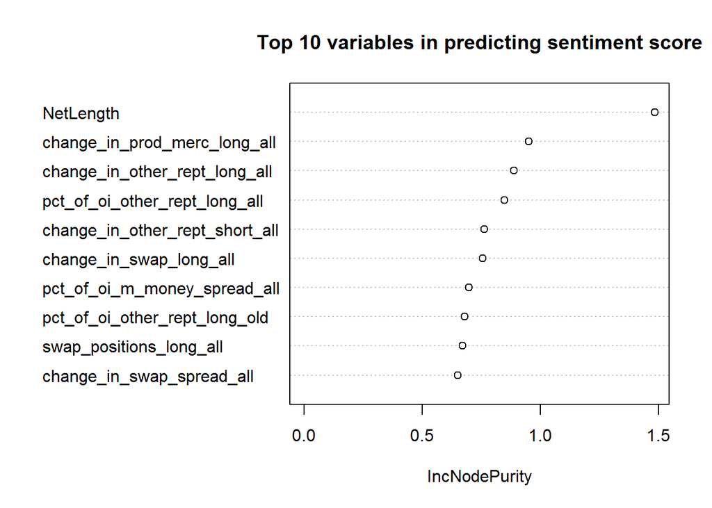

```r
#variable importance plot

n <- names(cotTweets[,16:ncol(cotTweets)])
f <- as.formula(paste("PriorWeeks.score ~", paste(n[!n %in% c("PriorWeeks.score", 'change_in_m_money_long_all', 'change_in_m_money_short_all')], collapse = " + ")))

cotTweetsTrain <- head(cotTweets, nrow(cotTweets)*2/3)
cotTweetsTest <- tail(cotTweets, nrow(cotTweets)-(nrow(cotTweets) * 2/3))

rf <- randomForest(f, data= cotTweetsTrain)
varImpPlot(rf, main = 'Top 10 variables in predicting sentiment score', n.var = 10)
```